# Proposal: Residential Housing Price Prediction

STAT 420, Summer 2017, Martynas Sapoka, Shailender Singh, Tesa Ho, Xiaoming Ji

# Overview

We propose to create a linear model that can predict residential home prices in Ames, Iowa based on several explanatory variables. This project is a practical example of using real world data that consists of a mix of different data types - nominal, ordinal, discrete, and continuous variables.

Our final project will incorporate the following topics covered in this course:

- Variable manipulation
- Outlier identification
- Data analysis and interpretation
- Model building
- Model evaluation

# Description of Dataset

The data set describes the sale of individual residential property in Ames, Iowa from 2006 to 2010 and contains 2,919 observations. There are 80 explanatory variables (23 nominal, 23 ordinal, 14 discrete, and 20 continuous) involved in assessing home values.

The 23 nominal variables identify various types of dwellings, materials, garages, and environmental conditions.

The 23 ordinal variables range from 2 to 28 representing Streets (gravel or paved) and Neighborhoods (areas within the Ames city limits).

The 14 discrete variables quantify the number of items for each house. Items include the number of kitchens, bedrooms, bathrooms, garage spaces and their respective location if the house has more than one floor.

The 20 continuous variables are related to area dimensions for each house. Variables include total dwelling square footage, total lot size, living area, and room dimensions.

Some important variables that may have strong correlation with sale price.

# Dataset Source

Inspired by [`Kaggle Competition`](https://www.kaggle.com/c/house-prices-advanced-regression-techniques), the data set is provided by Dean De Cock from Truman State University. The raw data comes directly from the Iowa State Assessorʻs Office. The initial Excel file contained 113 variables describing 3,970 property sales that had occurred in Ames, Iowa between 2006 and 2010. The variables were a mix of nominal, ordinal, continuous, and discrete variables used in calculation of assessed values and included physical property measurements in addition to computation variables used in the city’s assessment process. Variables that required specific housing or assessing knowledge or previous calculations were removed from the final dataset.

# Firstlook of the Data

We load the data and check the first few values of the response variable.

```r
library(readr)
house_data = read_csv("HousePrices/train.csv")

head(house_data[,c("SalePrice", "MSZoning", "LotArea", "OverallQual",
                   "TotRmsAbvGrd", "YearBuilt", "BedroomAbvGr", "BsmtFullBath",
                   "GarageCars")])
```

```
## # A tibble: 6 × 9
##   SalePrice MSZoning LotArea OverallQual TotRmsAbvGrd YearBuilt
##       <int>    <chr>   <int>       <int>        <int>     <int>
## 1    208500       RL    8450           7            8      2003
## 2    181500       RL    9600           6            6      1976
## 3    223500       RL   11250           7            6      2001
## 4    140000       RL    9550           7            7      1915
## 5    250000       RL   14260           8            9      2000
## 6    143000       RL   14115           5            5      1993
## # ... with 3 more variables: BedroomAbvGr <int>, BsmtFullBath <int>,
## #   GarageCars <int>
```

```r
price_model = lm(SalePrice ~ LotArea, data = house_data)
```

Let’s fit the data with a simple regression model with SalePrice as response and log(LotArea) as predictor.

```r
price_model_log = lm(SalePrice ~ log(LotArea), data = house_data)
```

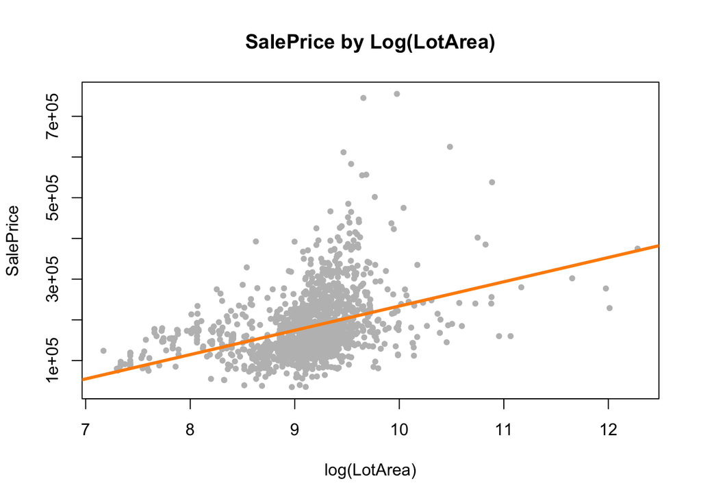

The regressin line does show some fit with the data.

We use the corrplot package in combination with the cor() function to plot the correlations between selected predictors.

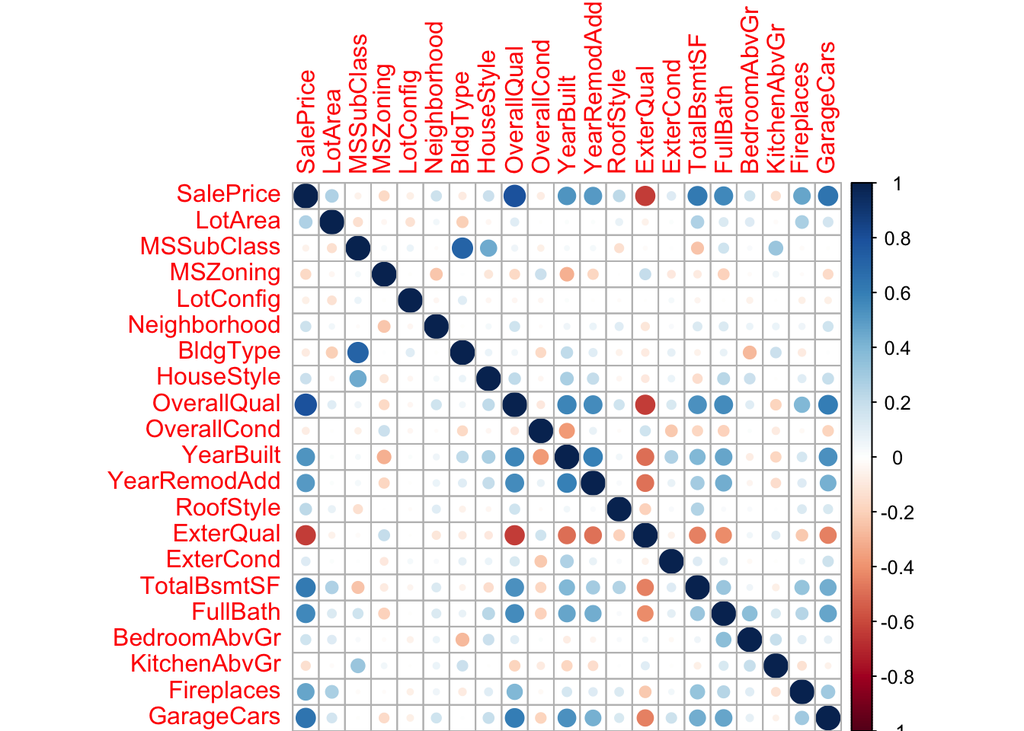

The test shows `OverallQual`, `TotalBsmtSF`, `YearBuilt`, `YearRemodAdd`, `ExterQual`, `FullBath`, `Fireplaces` has strong correlation with `SalePrice`.

## Data Exploration

Replace NA with 0ʻs

```r
house_data[is.na(house_data)] <- 0
```

Change factors.

```r
factors = c("MSSubClass", "MSZoning", "Street", "Alley", "LotShape",
            "LandContour", "Utilities", "LotConfig", "LandSlope",
            "Neighborhood", "Condition1", "Condition2", "BldgType",
            "HouseStyle", "OverallQual", "OverallCond", "RoofStyle",
            "RoofMatl", "Exterior1st", "Exterior2nd", "MasVnrType",
            "ExterQual", "ExterCond", "Foundation", "BsmtQual",
            "BsmtCond", "BsmtExposure", "BsmtFinType1", "BsmtFinType2",
            "Heating", "HeatingQC", "CentralAir", "Electrical",
            "KitchenQual", "Functional", "FireplaceQu", "GarageType",
            "GarageFinish", "GarageQual", "GarageCond", "PavedDrive",
            "PoolQC", "Fence", "MiscFeature", "MoSold", "SaleType",
            "SaleCondition")

num_house_data = house_data
for (name in factors){
  num_house_data[, name] = as.numeric(as.factor(name))
}

f_data = data.frame(sapply(num_house_data[, factors], function(x) as.numeric(as.factor(x))))
colnames(f_data) = factors
```

$## Correlation pairs plot##$

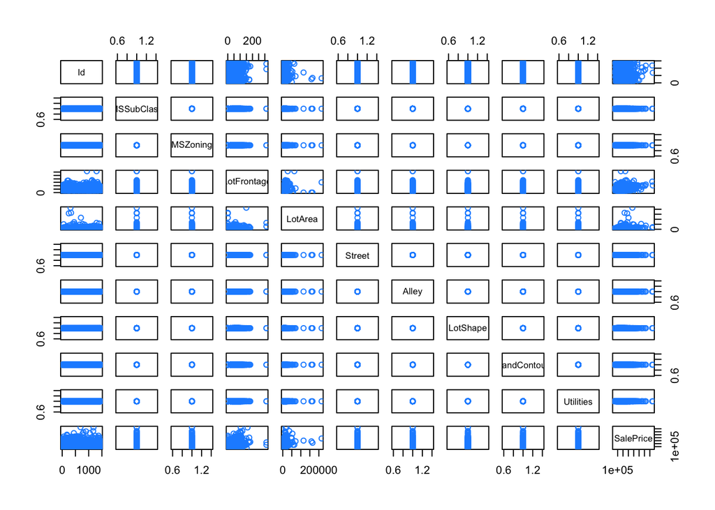

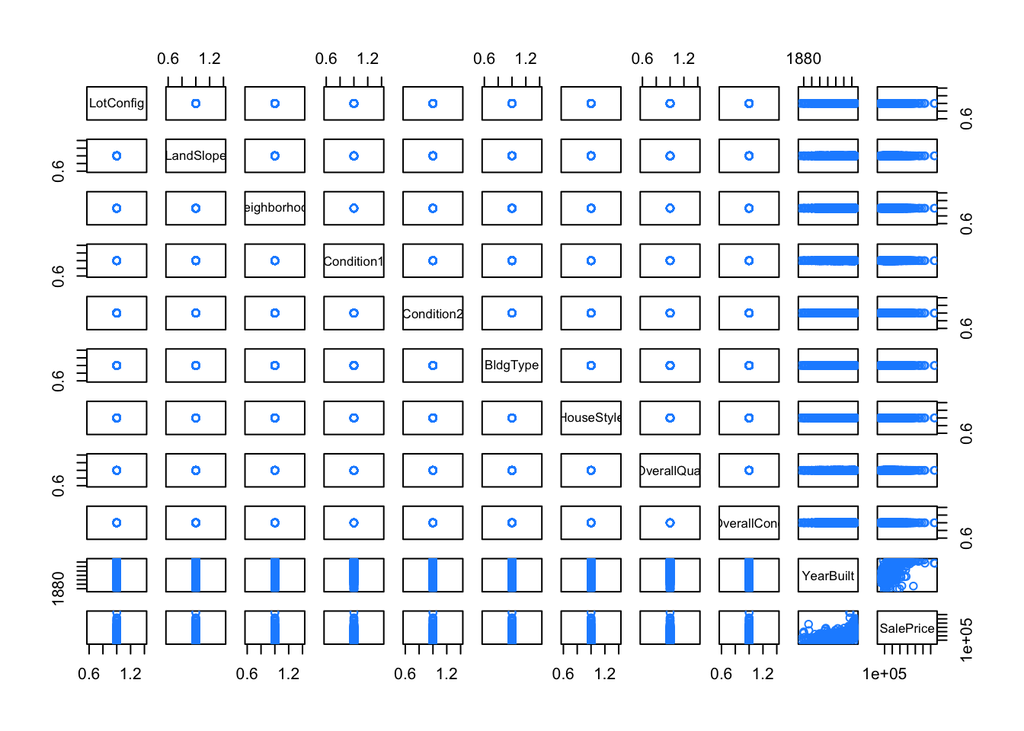

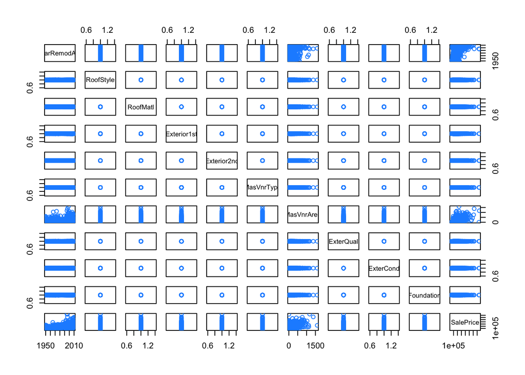

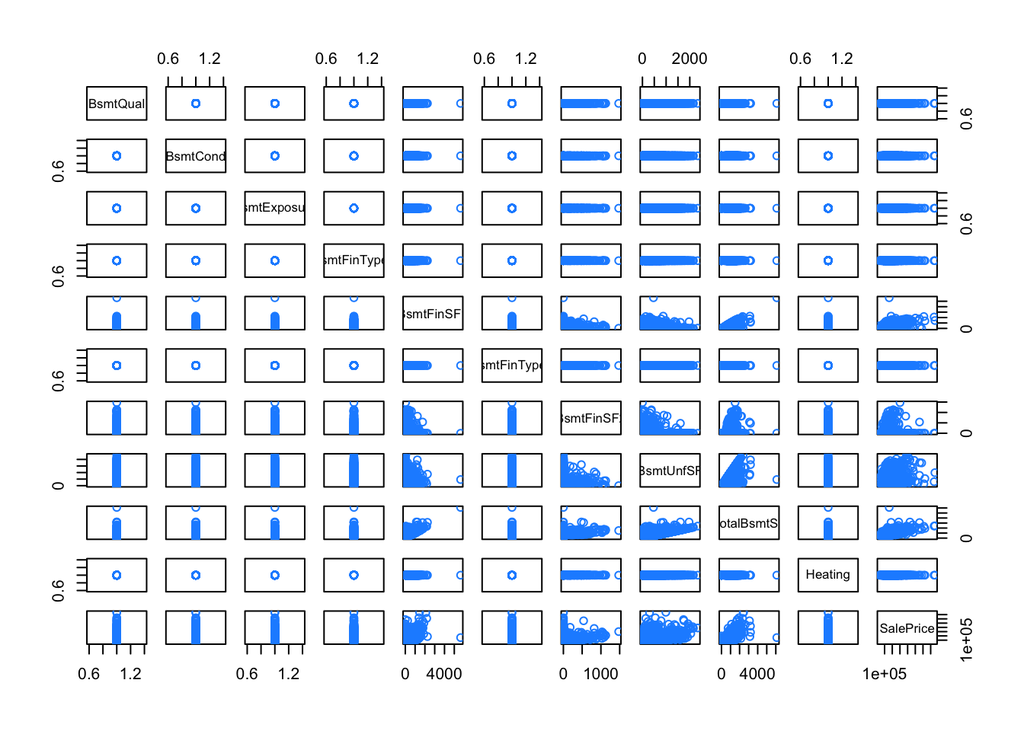

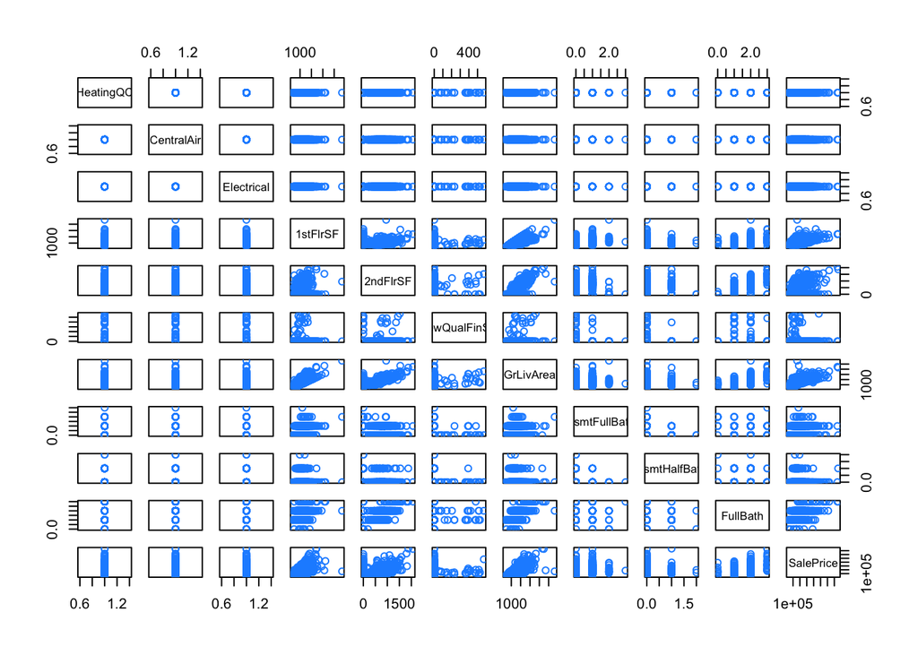

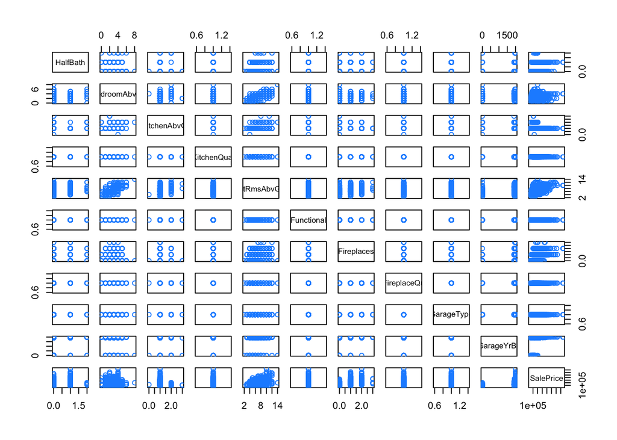

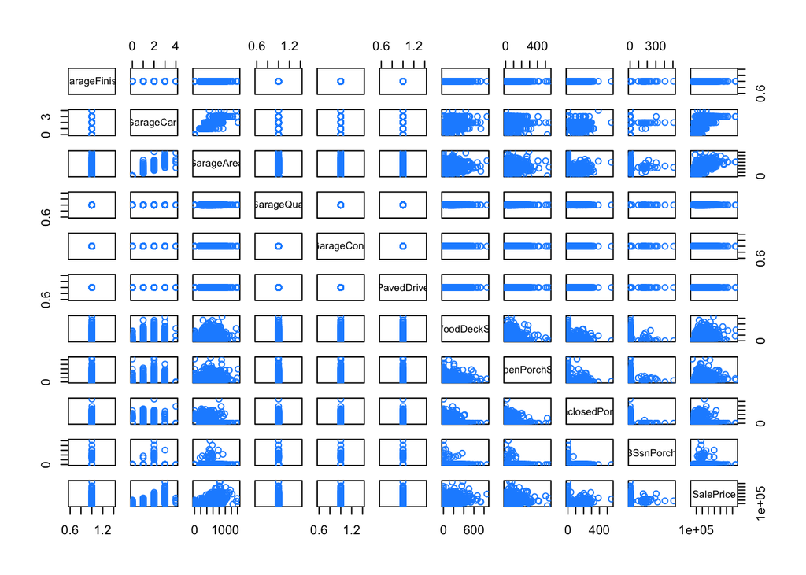

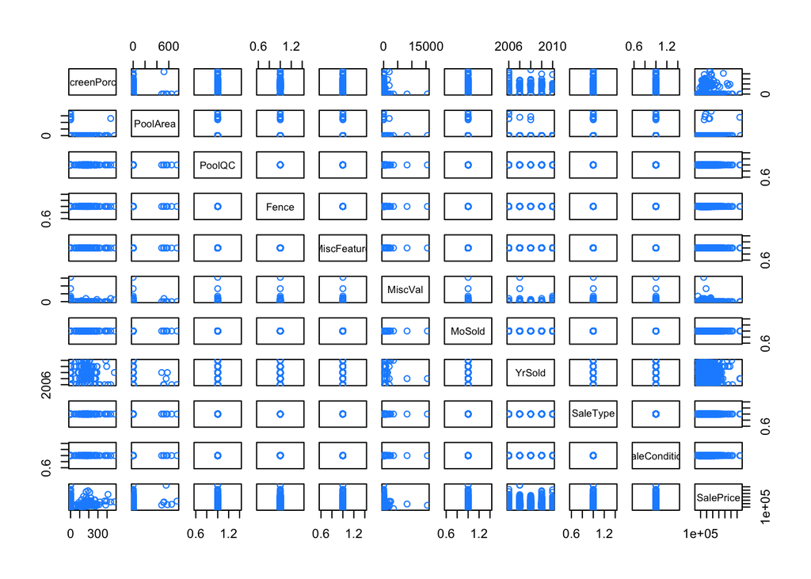

```r
# number of corr plots
house_cols = colnames(house_data)
x = (length(house_cols)-1)/10

for (i in 0:(x-1)){
  #print(i)
  #print(house_cols[(10*i + 1): (10*(i+1))])
  pairs(num_house_data[, c(house_cols[(10*i+1):(10*(i+1))], "SalePrice")], col="dodgerblue")
}
```

$## Examine non-factor variables ##$

```r
non_factors = c("LotFrontage", "LotArea", "YearBuilt",
                "YearRemodAdd", "MasVnrArea", "BsmtFinSF1",
                "BsmtFinSF2", "BsmtUnfSF", "TotalBsmtSF",
                "1stFlrSF", "2ndFlrSF", "LowQualFinSF",
                "GrLivArea", "BsmtFullBath", "BsmtHalfBath",
                "FullBath", "HalfBath", "BedroomAbvGr", "KitchenAbvGr",
                "TotRmsAbvGrd", "Fireplaces", "GarageYrBlt",
                "GarageCars", "GarageArea", "WoodDeckSF",
                "OpenPorchSF", "EnclosedPorch", "3SsnPorch",
                "ScreenPorch", "PoolArea", "MiscVal", "SalePrice")

nf_data = data.frame(sapply(house_data[, non_factors], function(x) as.numeric(x)))
colnames(nf_data) = non_factors
nf_corr = cor(nf_data)
sort(nf_corr["SalePrice",], decreasing=TRUE)
```

```
##     SalePrice     GrLivArea    GarageCars    GarageArea   TotalBsmtSF
##    1.00000000    0.70862448    0.64040920    0.62343144    0.61358055
##      1stFlrSF      FullBath  TotRmsAbvGrd     YearBuilt  YearRemodAdd
##    0.60585218    0.56066376    0.53372316    0.52289733    0.50710097
##    MasVnrArea    Fireplaces    BsmtFinSF1    WoodDeckSF      2ndFlrSF
##    0.47261450    0.46692884    0.38641981    0.32441344    0.31933380
##   OpenPorchSF      HalfBath       LotArea   GarageYrBlt  BsmtFullBath
##    0.31585623    0.28410768    0.26384335    0.26136644    0.22712223
##     BsmtUnfSF   LotFrontage  BedroomAbvGr   ScreenPorch      PoolArea
##    0.21447911    0.20962394    0.16821315    0.11144657    0.09240355
##     3SsnPorch    BsmtFinSF2  BsmtHalfBath       MiscVal  LowQualFinSF
##    0.04458367   -0.01137812   -0.01684415   -0.02118958   -0.02560613
## EnclosedPorch  KitchenAbvGr
##   -0.12857796   -0.13590737
```

$## Histogram ##$

Histograms of the non-factor variables that are significant.

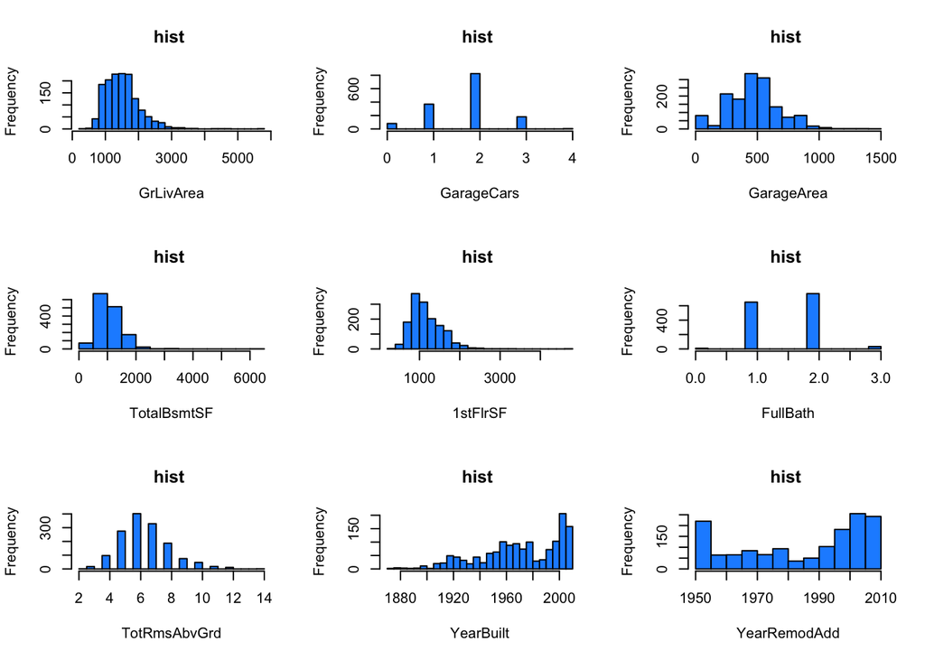

```r
top_corrs = sort(nf_corr["SalePrice", ], decreasing=TRUE)[sort(nf_corr["SalePrice", ], decreasing=TRUE) > 0]
top_corrs_name = names(top_corrs[2:length(top_corrs)])

par(mfrow=c(3,3))
for (name in top_corrs_name[1:9]){
  hist(nf_data[,name], breaks=20, xlab=name, main="hist ", col="dodgerblue")
}
```

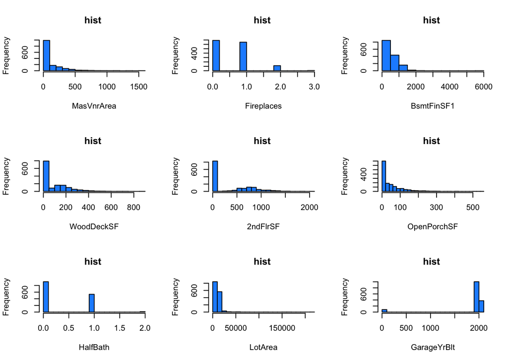

```r
par(mfrow=c(3,3))
for (name in top_corrs_name[10:18]){
  hist(nf_data[,name], breaks=20, xlab=name, main="hist ", col="dodgerblue")
}
```

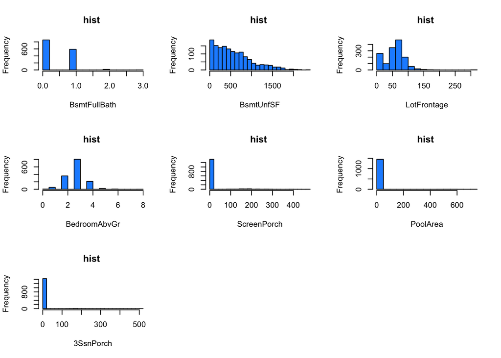

```r
par(mfrow=c(3,3))
for (name in top_corrs_name[19:25]){
  hist(nf_data[,name], breaks=20, xlab=name, main="hist ", col="dodgerblue")
}
```

$## SalePrice vs Top Correlated Features ##$

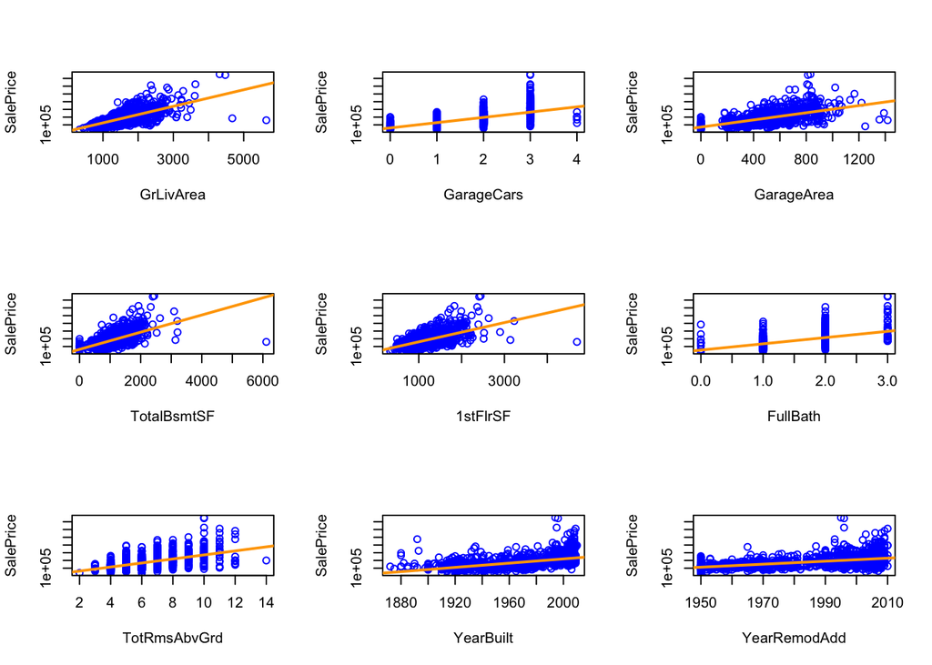

```r
par(mfrow=c(3,3))
for (name in top_corrs_name[1:9]){
  plot(nf_data[,name], house_data$SalePrice, xlab=name, ylab="SalePrice", col="blue")
  p_mod = lm(house_data$SalePrice ~ nf_data[,name])
  abline(coef(p_mod)[1], coef(p_mod)[2], col="orange", lwd=2)
}
```

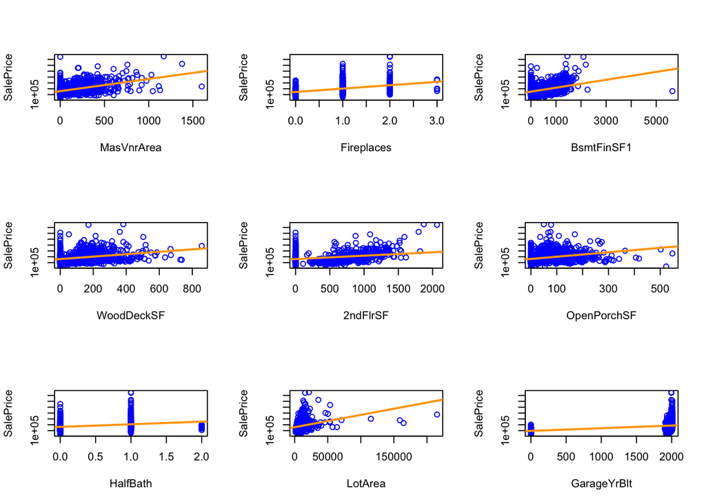

```r
par(mfrow=c(3,3))
for (name in top_corrs_name[10:18]){
  plot(nf_data[,name], house_data$SalePrice, xlab=name, ylab="SalePrice", col="blue")
  p_mod = lm(house_data$SalePrice ~ nf_data[,name])
  abline(coef(p_mod)[1], coef(p_mod)[2], col="orange", lwd=2)
}
```

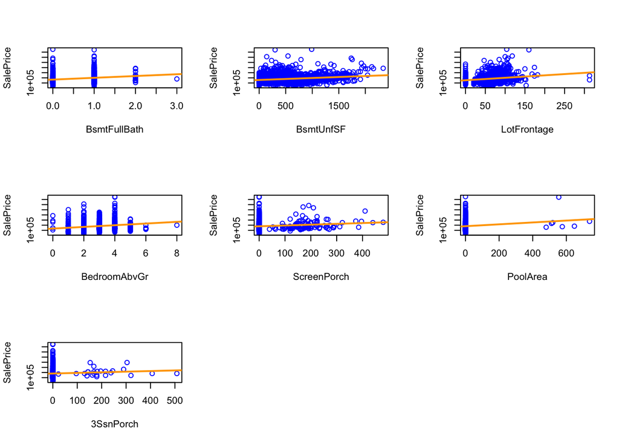

```r
par(mfrow=c(3,3))
for (name in top_corrs_name[19:25]){
  plot(nf_data[,name], house_data$SalePrice, xlab=name, ylab="SalePrice", col="blue")
  p_mod = lm(house_data$SalePrice ~ nf_data[,name])
  abline(coef(p_mod)[1], coef(p_mod)[2], col="orange", lwd=2)
}
```

## Build Models

$## Split Model into Train & Test Sets ##$

```r
set.seed(42)
train_index = sample(1:nrow(house_data), nrow(house_data)*2/3) # randomly chosen observations for training
train_data  = house_data[train_index, ]
test_data   = house_data[-train_index, ]
```

$## Model w/ Top Correlated Predictors ##$

```r
top_corrs_data = train_data[ , c("SalePrice", top_corrs_name)]
top_corrs_mod = lm(SalePrice ~ ., data=top_corrs_data)
summary(top_corrs_mod)
```

```
##
## Call:
## lm(formula = SalePrice ~ ., data = top_corrs_data)
##
## Residuals:
##     Min      1Q  Median      3Q     Max
## -505005  -18224   -3149   16707  311760
##
## Coefficients:
##                Estimate Std. Error t value Pr(>|t|)
## (Intercept)  -1.811e+06  1.606e+05 -11.277  < 2e-16 ***
## GrLivArea     1.367e+01  2.631e+01   0.519  0.60358
## GarageCars    2.011e+04  3.822e+03   5.261 1.77e-07 ***
## GarageArea   -9.891e-03  1.279e+01  -0.001  0.99938
## TotalBsmtSF   1.671e+01  9.233e+00   1.810  0.07058 .
## `1stFlrSF`    4.227e+01  2.699e+01   1.566  0.11762
## FullBath     -1.772e+03  3.696e+03  -0.479  0.63182
## TotRmsAbvGrd  3.011e+03  1.572e+03   1.916  0.05568 .
## YearBuilt     4.158e+02  6.486e+01   6.411 2.27e-10 ***
## YearRemodAdd  5.205e+02  7.694e+01   6.766 2.32e-11 ***
## MasVnrArea    3.630e+01  7.522e+00   4.826 1.62e-06 ***
## Fireplaces    9.663e+03  2.344e+03   4.123 4.07e-05 ***
## BsmtFinSF1    9.801e+00  7.890e+00   1.242  0.21444
## WoodDeckSF    3.584e+01  1.029e+01   3.482  0.00052 ***
## `2ndFlrSF`    4.843e+01  2.673e+01   1.812  0.07028 .
## OpenPorchSF   1.695e+01  2.027e+01   0.836  0.40314
## HalfBath     -5.052e+03  3.562e+03  -1.418  0.15643
## LotArea       1.456e-01  1.685e-01   0.864  0.38778
## GarageYrBlt  -8.534e+00  3.438e+00  -2.483  0.01322 *
## BsmtFullBath  8.509e+03  3.279e+03   2.595  0.00960 **
## BsmtUnfSF     6.821e+00  8.189e+00   0.833  0.40506
## LotFrontage   3.203e+01  3.696e+01   0.866  0.38647
## BedroomAbvGr -1.044e+04  2.197e+03  -4.753 2.31e-06 ***
## ScreenPorch   1.848e+01  2.523e+01   0.733  0.46400
## PoolArea     -2.662e+01  2.888e+01  -0.922  0.35674
## `3SsnPorch`   3.001e+01  3.605e+01   0.833  0.40529
## ---
## Signif. codes:  0 '***' 0.001 '**' 0.01 '*' 0.05 '.' 0.1 ' ' 1
##
## Residual standard error: 37110 on 947 degrees of freedom
## Multiple R-squared:  0.7705, Adjusted R-squared:  0.7645
## F-statistic: 127.2 on 25 and 947 DF,  p-value: < 2.2e-16
```

Model with significant correlated predictors

```r
pvalues = coefficients(summary(top_corrs_mod))[,"Pr(>|t|)"]
sig_names = names(pvalues[pvalues < 0.01])
sig_names = sig_names[2:length(sig_names)]
sig_data = top_corrs_data[, c(sig_names,"SalePrice")]
sig_mod = lm(SalePrice ~ ., data=sig_data)
summary(sig_mod)
```

```
##
## Call:
## lm(formula = SalePrice ~ ., data = sig_data)
##
## Residuals:
##     Min      1Q  Median      3Q     Max
## -209564  -27133   -3176   21404  455744
##
## Coefficients:
##                Estimate Std. Error t value Pr(>|t|)
## (Intercept)  -2.321e+06  1.610e+05 -14.413  < 2e-16 ***
## GarageCars    3.046e+04  2.396e+03  12.711  < 2e-16 ***
## YearBuilt     3.357e+02  6.531e+01   5.140 3.33e-07 ***
## YearRemodAdd  8.653e+02  8.689e+01   9.959  < 2e-16 ***
## MasVnrArea    7.892e+01  8.502e+00   9.283  < 2e-16 ***
## Fireplaces    2.571e+04  2.505e+03  10.265  < 2e-16 ***
## WoodDeckSF    6.132e+01  1.175e+01   5.217 2.22e-07 ***
## BsmtFullBath  1.613e+04  2.850e+03   5.657 2.02e-08 ***
## BedroomAbvGr  1.094e+04  1.818e+03   6.016 2.54e-09 ***
## ---
## Signif. codes:  0 '***' 0.001 '**' 0.01 '*' 0.05 '.' 0.1 ' ' 1
##
## Residual standard error: 44350 on 964 degrees of freedom
## Multiple R-squared:  0.6664, Adjusted R-squared:  0.6637
## F-statistic: 240.8 on 8 and 964 DF,  p-value: < 2.2e-16
```

## Test Models

Compare models on test data using RMSE as metric.

```r
## function to calculate rmse
rmse  = function(actual, predicted) {
  sqrt(mean((actual - predicted) ^ 2, na.rm=TRUE))
}
```

```r
## function to compare models using rmse
compareModels <- function(models, modelNames){
  train_error = rep(0, length(modelNames))
  test_error = rep(0, length(modelNames))
  for (i in 1:length(modelNames)){
    ## train errors
    train_error[i] = rmse(train_data$SalePrice, predict(models[[ modelNames[i] ]], newdata=train_data))
    ## test errors
    test_error[i] = rmse(test_data$SalePrice, predict(models[[ modelNames[i] ]], newdata=test_data))
  }
  df = data.frame("models"=modelNames, "trainErrors"=train_error, "testErrors"=test_error)
  return(df)
}
```

## Results

```r
modelNames = c("topCorrMod", "sigMod")
models = vector(mode="list", length = length(modelNames))
models[["topCorrMod"]] = top_corrs_mod
models[["sigMod"]] = sig_mod

compareModels(models, modelNames)
```

```
##       models trainErrors testErrors
## 1 topCorrMod    36613.96   42572.06
## 2     sigMod    44144.73   54489.50
```